# Microbiome Analysis v3 - ASV Finder

Abbott Carbohydrate Obesity Project

2025-10-02

## 0.1 1. Analysis Roadmap

This v3 report refines the v2 workflow to deliver a cleaner, more cohesive analysis with harmonized graphics, consistent statistical modeling, and dynamic interpretation. The key updates include:

- Streamlined data processing with shared helper functions and reproducible checks.
- Consistent mixed-effects modeling that respects the repeated-measures design (`SubjectID` random intercepts).
- False discovery rate control (Benjamini–Hochberg) applied to all multi-comparison contexts.
- Publication-quality visual styling and unified color palettes for categorical variables.
- Interpretation blocks populated via inline code so narrative text always reflects current outputs.
- Expanded differential-abundance section spanning corncob, ANCOM-BC2, ALDEx2, LEfSe, MaAsLin2, ADAPT, random forest, and consensus summaries.
- Dedicated focus on 48 h responses, baseline clustering, and analyses with combined groups for improved power when appropriate.

## 0.2 2. Libraries, Options, and Helper Functions

```r
required_packages <- c(
  "tidyverse", "readr", "janitor", "glue", "scales", "patchwork",
  "phyloseq", "microbiome", "vegan", "betapart", "ape", "Biostrings",
  "broom", "broom.mixed", "lme4", "lmerTest", "emmeans", "performance",
  "rstatix", "ggpubr", "ggtext", "cowplot", "ggsci", "scico",
  "here", "corncob", "ANCOMBC", "ALDEx2", "microbiomeMarker", "ADAPT",
  "Maaslin2", "gt", "cluster", "nlme", "randomForest", "ranger", "caret", "phyloseqGraphTest"
)

# Function to install missing packages
install_missing_packages <- function(packages) {
  missing_packages <- packages[!vapply(packages, requireNamespace, logical(1), quietly = TRUE)]

  if (length(missing_packages) > 0) {
    cat("Installing missing packages:", paste(missing_packages, collapse = ", "), "\n")

    # Bioconductor packages
    bioc_packages <- c("phyloseq", "microbiome", "Biostrings", "ANCOMBC", "ALDEx2", "microbiomeMarker", "Maaslin2", "phyloseqGraphTest", "ADAPT")
    bioc_to_install <- intersect(missing_packages, bioc_packages)

    # CRAN packages
    cran_to_install <- setdiff(missing_packages, bioc_packages)

    # Install Bioconductor packages
    if (length(bioc_to_install) > 0) {
      if (!requireNamespace("BiocManager", quietly = TRUE)) {
        install.packages("BiocManager")
      }
      BiocManager::install(bioc_to_install, update = FALSE, ask = FALSE)
    }

    # Install CRAN packages
    if (length(cran_to_install) > 0) {
      install.packages(cran_to_install, repos = "https://cloud.r-project.org/")
    }

    cat("Package installation completed.\n")
  }
}

# Install missing packages
install_missing_packages(required_packages)

invisible(lapply(required_packages, library, character.only = TRUE))

options(dplyr.summarise.inform = FALSE)
set.seed(12345)

# Output directory for derived artefacts
outputs_dir <- here::here("outputs")
dir.create(outputs_dir, showWarnings = FALSE, recursive = TRUE)
```

```r
# Harmonized aesthetic ---------------------------------------------------

palette_group <- setNames(scico::scico(2, palette = "berlin"), c("Healthy", "Obese"))
palette_carbohydrate <- setNames(c("#1f77b4", "#ff7f0e", "#2ca02c"), c("No Added Carb", "RDC", "SDC"))
palette_timepoint <- setNames(scico::scico(2, palette = "roma"), c("0H", "48H"))

palette_cluster <- setNames(scico::scico(6, palette = "batlow"), paste0("Cluster", seq_len(6)))

custom_theme <- function(base_size = 12, base_family = "sans") {
  theme_minimal(base_size = base_size, base_family = base_family) +
    theme(
      panel.grid.major = element_line(color = "grey85", linewidth = 0.4),
      panel.grid.minor = element_blank(),
      panel.border = element_rect(color = "grey65", fill = NA, linewidth = 0.4),
      plot.title = element_text(face = "bold", size = base_size + 2),
      plot.subtitle = element_text(size = base_size, margin = ggplot2::margin(b = 6)),
      plot.caption = element_text(size = base_size - 2, color = "grey40"),
      strip.text = element_text(face = "bold", size = base_size - 1),
      legend.position = "right",
      legend.title = element_text(face = "bold"),
      legend.background = element_rect(fill = "white", color = NA)
    )
}

theme_set(custom_theme())

format_p <- function(p) {
  case_when(
    is.na(p) ~ "NA",
    p < 0.001 ~ "<0.001",
    TRUE ~ sprintf("%.3f", p)
  )
}

fdr_adjust <- function(p) stats::p.adjust(p, method = "BH")

add_fdr <- function(tbl, p_col = "p_value", new_col = "fdr") {
  tbl %>% dplyr::mutate(!!new_col := fdr_adjust(.data[[p_col]]))
}

anova_table <- function(model) {
  if (inherits(model, "lme")) {
    anova_df <- nlme::anova.lme(model, type = "marginal") %>%
      rownames_to_column("term") %>%
      as_tibble() %>%
      janitor::clean_names() %>%
      dplyr::rename(
        num_df = num_df,
        den_df = den_df,
        f_value = f_value,
        p_value = p_value
      )

    if (!"p_value" %in% names(anova_df)) {
      warning("anova.lme output did not contain p-values; returning empty tibble")
      return(tibble())
    }

    anova_df %>% add_fdr("p_value", "fdr")
  } else {
    anova(model, type = 3) %>%
      rownames_to_column("term") %>%
      as_tibble() %>%
      janitor::clean_names() %>%
      dplyr::rename(p_value = pr_greater_f_) %>%
      add_fdr("p_value", "fdr")
  }
}

emmeans_pairs <- function(model, specs, adjust = "BH", by = NULL) {
  emmeans::emmeans(model, specs = specs, by = by) %>%
    emmeans::contrast(method = "pairwise", adjust = adjust) %>%
    broom::tidy()
}
```

```r
# Helper utilities -------------------------------------------------------

collapse_taxa <- function(ps_obj, rank = "Genus", top_n = 15) {
  ps_rel <- microbiome::transform(ps_obj, "compositional")
  tax_rank <- tax_table(ps_rel)[, rank]
  tax_rank[is.na(tax_rank) | tax_rank == ""] <- paste0(rank, "_Unassigned")
  tax_table(ps_rel)[, rank] <- tax_rank

  ps_rank <- tax_glom(ps_rel, taxrank = rank, NArm = FALSE)
  abund <- taxa_sums(ps_rank)
  keep <- rank(abund, ties.method = "first") > (ntaxa(ps_rank) - top_n)
  ps_keep <- prune_taxa(keep, ps_rank)
  other <- prune_taxa(!keep, ps_rank)

  if (ntaxa(other) > 0) {
    other_sum <- tax_table(other)[, rank]
    tax_table(other)[, rank] <- "Other"
    ps_rank <- merge_phyloseq(ps_keep, other)
  } else {
    ps_rank <- ps_keep
  }

  ps_rank
}

plot_bar_compositional <- function(ps_obj, fill_var, facet_var = NULL, rank = "Genus", top_n = 15) {
  ps_rank <- collapse_taxa(ps_obj, rank = rank, top_n = top_n)
  df <- psmelt(ps_rank)

  fill_palette <- scico::scico(length(unique(df[[rank]])) + 1, palette = "batlow")

  ggplot(df, aes(x = .data[[fill_var]], y = Abundance, fill = .data[[rank]])) +
    geom_col(position = "stack") +
    scale_y_continuous(labels = scales::percent) +
    scale_fill_manual(values = fill_palette, guide = guide_legend(ncol = 1)) +
    labs(
      x = NULL,
      y = "Relative abundance",
      fill = rank
    ) +
    custom_theme() +
    theme(axis.text.x = element_text(angle = 45, hjust = 1)) +
    facet_wrap(vars(.data[[facet_var]]), scales = "free_x") %||%
    identity
}

format_emm_table <- function(tbl) {
  tbl %>%
    dplyr::mutate(
      estimate = round(estimate, 3),
      conf.low = round(conf.low, 3),
      conf.high = round(conf.high, 3),
      p_raw = p.value,
      fdr = p.adjust(p.value, method = "BH")
    ) %>%
    dplyr::mutate(
      p.value = format_p(p_raw),
      fdr = format_p(fdr)
    ) %>%
    dplyr::select(-p_raw)
}

inline_glue <- function(...) {
  glue::glue_data(.x = environment(), ...)
}

`%||%` <- function(x, y) if (!is.null(x)) x else y

cache_rds <- function(path, code) {
  if (file.exists(path)) {
    message("Loading cached result: ", path)
    readRDS(path)
  } else {
    dir.create(dirname(path), showWarnings = FALSE, recursive = TRUE)
    message("Caching result to: ", path)
    result <- code
    if (!is.null(result)) {
      saveRDS(result, path)
    }
    result
  }
}

pull_safe <- function(tbl, col) {
  if (is.null(tbl) || nrow(tbl) == 0 || !(col %in% names(tbl))) {
    return(character())
  }
  tbl[[col]]
}

first_match_col <- function(tbl, candidates) {
  candidates <- candidates[candidates %in% names(tbl)]
  if (length(candidates) == 0) return(NULL)
  candidates[[1]]
}
```

## 0.3 3. Data Import and Curation

```r
metadata_raw <- readr::read_tsv("sample.metadata.tsv", show_col_types = FALSE) %>%
  janitor::clean_names()

metadata <- metadata_raw %>%
  separate(customer_label, into = c("subject_id", "replicate_code", "timepoint"), sep = "\\.", remove = FALSE) %>%
  dplyr::mutate(
    carbohydrate = case_when(
      str_detect(replicate_code, "R") ~ "RDC",
      str_detect(replicate_code, "S") ~ "SDC",
      TRUE ~ "No Added Carb"
    ),
    carbohydrate = factor(carbohydrate, levels = c("No Added Carb", "RDC", "SDC")),
    timepoint = factor(timepoint, levels = c("0H", "48H")),
    replicate = readr::parse_number(replicate_code) %>% replace_na(1)
  ) %>%
  dplyr::rename(SampleID = sample_id) %>%
  dplyr::select(SampleID, subject_id, timepoint, carbohydrate, replicate, customer_label, raw_seq_files)

healthy_lookup <- readr::read_tsv(
  file = here::here("zr24558.16S_250813.zymo", "1.Healthy.TimepointComparism..Bac16Sv34", "Sample_Information", "sample.metadata.csv"),
  show_col_types = FALSE
) %>%
  janitor::clean_names() %>%
  separate(customer_label, into = c("subject_id", "tmp", "tp"), sep = "\\.", remove = FALSE) %>%
  dplyr::distinct(subject_id) %>%
  dplyr::mutate(group = "Healthy")

metadata <- metadata %>%
  dplyr::mutate(
    group = if_else(subject_id %in% healthy_lookup$subject_id, "Healthy", "Obese"),
    group = factor(group, levels = c("Healthy", "Obese")),
    subject_id = factor(subject_id)
  )

metadata_summary <- metadata %>%
  dplyr::count(group, carbohydrate, timepoint, name = "n_samples")

subject_counts <- metadata %>%
  dplyr::distinct(subject_id, group) %>%
  dplyr::count(group, name = "n_subjects")

metadata_overview <- metadata_summary %>%
  dplyr::group_by(group) %>%
  dplyr::summarise(total = sum(n_samples), .groups = "drop") %>%
  dplyr::left_join(subject_counts, by = "group")
```

**Cohort coverage**

- Samples: 297
- Subjects: 33
- Group allocation: Healthy: 14 subjects, 136 samples; Obese: 19 subjects, 161 samples
- Carbohydrate distribution: No Added Carb, RDC, SDC

```r
metadata_summary %>%
  dplyr::arrange(group, carbohydrate, timepoint) %>%
  gt::gt(rowname_col = "timepoint") %>%
  gt::tab_header(title = "Sample counts by group, carbohydrate, and timepoint") %>%
  gt::fmt_number(columns = "n_samples", decimals = 0)
```

Sample counts by group, carbohydrate, and timepoint

|  | group | carbohydrate | n_samples |
| --- | --- | --- | --- |
| 0H | Healthy | No Added Carb | 12 |
| 48H | Healthy | No Added Carb | 14 |
| 0H | Healthy | RDC | 28 |
| 48H | Healthy | RDC | 27 |
| 0H | Healthy | SDC | 27 |
| 48H | Healthy | SDC | 28 |
| 0H | Obese | No Added Carb | 14 |
| 48H | Obese | No Added Carb | 20 |
| 0H | Obese | RDC | 28 |
| 48H | Obese | RDC | 35 |
| 0H | Obese | SDC | 28 |
| 48H | Obese | SDC | 36 |

### 0.3.1 3.1 Amplicon Sequence Variants and Taxonomy

```r
asv_raw <- readr::read_tsv("dada2_asv_2/asv_table.tsv", show_col_types = FALSE)

asv_ids <- stringr::str_extract(asv_raw$ASV_ID, "ASV_\\d+")

otu_mat <- asv_raw %>%
  dplyr::select(-ASV_ID, -Sequence, -Length, -Total_Abundance, -Relative_Abundance) %>%
  as.data.frame()

colnames(otu_mat) <- stringr::str_remove(colnames(otu_mat), "_filtered$")
rownames(otu_mat) <- asv_ids

taxonomy_raw <- readr::read_tsv("dada2_asv_2/sintax_bacteria_taxonomy.tsv", show_col_types = FALSE)
rownames(taxonomy_raw) <- paste0("ASV_", 1:nrow(taxonomy_raw))

taxonomy_mat <- taxonomy_raw %>%
  dplyr::mutate(ASV = stringr::str_extract(ASV_ID, "ASV_\\d+")) %>%
  dplyr::select(ASV, Kingdom, Phylum, Class, Order, Family, Genus, Species) %>%
  dplyr::mutate(across(everything(), ~ replace_na(., "Unassigned"))) %>%
  column_to_rownames("ASV") %>%
  as.matrix()

stopifnot(all(rownames(otu_mat) %in% rownames(taxonomy_mat)))

metadata_ps <- metadata %>%
  dplyr::mutate(SampleID = as.character(SampleID)) %>%
  column_to_rownames("SampleID")

common_samples <- intersect(colnames(otu_mat), rownames(metadata_ps))
otu_mat <- otu_mat[, common_samples]
metadata_ps <- metadata_ps[common_samples, ]

ps <- phyloseq(
  otu_table(as.matrix(otu_mat), taxa_are_rows = TRUE),
  sample_data(metadata_ps),
  tax_table(taxonomy_mat[rownames(otu_mat), ])
)

ps <- prune_taxa(taxa_sums(ps) > 0, ps)
ps <- prune_samples(sample_sums(ps) > 0, ps)

sample_data(ps)$SubjectID <- sample_data(ps)$subject_id
sample_data(ps)$Group <- sample_data(ps)$group
sample_data(ps)$Carbohydrate <- sample_data(ps)$carbohydrate
sample_data(ps)$Timepoint <- sample_data(ps)$timepoint

ps_rel <- microbiome::transform(ps, "compositional")
```

```r
seq_depth <- tibble(
  SampleID = sample_names(ps),
  reads = sample_sums(ps)
) %>%
  dplyr::left_join(as_tibble(metadata, .name_repair = "minimal"), by = "SampleID")

coverage_stats <- seq_depth %>%
  dplyr::summarise(
    min_reads = min(reads),
    median_reads = median(reads),
    max_reads = max(reads)
  )

coverage_stats
```

| min_reads | median_reads | max_reads |
| --- | --- | --- |
| 3142 | 117356 | 200611 |

**Retained ASV reads** – minimum 3,142, median 117,356, maximum 200,611 reads per sample represented in the denoised ASV table after filtering and chimera removal.

## 0.4 4. Alpha Diversity

```r
alpha_metrics <- estimate_richness(ps, measures = c("Observed", "Shannon", "Simpson")) %>%
  rownames_to_column("SampleID")

alpha_long <- alpha_metrics %>%
  pivot_longer(cols = -SampleID, names_to = "metric", values_to = "value") %>%
  dplyr::left_join(as_tibble(metadata, .name_repair = "minimal"), by = "SampleID") %>%
  dplyr::mutate(
    metric = factor(metric, levels = c("Shannon", "Observed", "Simpson"))
  )

prep_mixed_data <- function(data, extra_vars = character()) {
  keep_vars <- unique(c("value", "subject_id", extra_vars))
  keep_vars <- keep_vars[keep_vars %in% names(data)]

  data <- data %>%
    dplyr::select(dplyr::all_of(keep_vars)) %>%
    tidyr::drop_na()

  if (nrow(data) == 0) {
    return(NULL)
  }

  data <- droplevels(as.data.frame(data))

  categorical_vars <- intersect(c("subject_id", extra_vars, "baseline_cluster"), names(data))
  data[categorical_vars] <- lapply(data[categorical_vars], function(x) factor(x))

  if (any(vapply(data[categorical_vars], function(x) length(levels(x)) < 2, logical(1)))) {
    return(NULL)
  }

  data
}

safe_lme <- function(fixed, random, data, extra_vars = character()) {
  data_prepped <- prep_mixed_data(data, extra_vars)
  if (is.null(data_prepped)) {
    return(NULL)
  }

  tryCatch(
    nlme::lme(
      fixed = fixed,
      data = data_prepped,
      random = random,
      method = "REML",
      control = nlme::lmeControl(opt = "optim")
    ),
    error = function(e) {
      message("Mixed model failed: ", e$message)
      NULL
    }
  )
}

fit_alpha_model <- function(df) {
  safe_lme(
    fixed = value ~ group * carbohydrate + group * timepoint + carbohydrate * timepoint,
    random = ~1 | subject_id,
    data = df,
    extra_vars = c("group", "carbohydrate", "timepoint")
  )
}

fit_alpha_model_collapsed <- function(df) {
  safe_lme(
    fixed = value ~ carbohydrate * timepoint,
    random = ~1 | subject_id,
    data = df,
    extra_vars = c("carbohydrate", "timepoint")
  )
}

fit_alpha_model_48h <- function(df) {
  df_levels <- df %>%
    dplyr::filter(!is.na(value)) %>%
    droplevels()

  group_levels <- dplyr::n_distinct(df_levels$group)
  carb_levels <- dplyr::n_distinct(df_levels$carbohydrate)

  if (group_levels <= 1 && carb_levels <= 1) {
    return(NULL)
  }

  if (group_levels > 1 && carb_levels > 1) {
    fixed_formula <- value ~ group * carbohydrate
    extra_vars <- c("group", "carbohydrate")
  } else if (carb_levels > 1) {
    fixed_formula <- value ~ carbohydrate
    extra_vars <- c("carbohydrate")
  } else {
    fixed_formula <- value ~ group
    extra_vars <- c("group")
  }

  safe_lme(
    fixed = fixed_formula,
    random = ~1 | subject_id,
    data = df,
    extra_vars = extra_vars
  )
}

fit_cluster_model <- function(df) {
  safe_lme(
    fixed = value ~ baseline_cluster * carbohydrate,
    random = ~1 | subject_id,
    data = df,
    extra_vars = c("baseline_cluster", "carbohydrate")
  )
}

alpha_metrics_vec <- levels(alpha_long$metric)
alpha_results <- vector("list", length(alpha_metrics_vec))
names(alpha_results) <- alpha_metrics_vec

for (metric_name in alpha_metrics_vec) {
  df_metric <- alpha_long %>%
    dplyr::filter(metric == metric_name) %>%
    droplevels()

  model <- fit_alpha_model(df_metric)
  anova_tbl <- if (is.null(model)) tibble::tibble() else anova_table(model)

  alpha_results[[metric_name]] <- list(
    data = df_metric,
    model = model,
    anova = anova_tbl
  )
}

alpha_models <- tibble(
  metric = alpha_metrics_vec,
  data = lapply(alpha_metrics_vec, function(m) alpha_results[[m]]$data),
  model = lapply(alpha_metrics_vec, function(m) alpha_results[[m]]$model),
  anova = lapply(alpha_metrics_vec, function(m) alpha_results[[m]]$anova)
)

alpha_significance <- alpha_models %>%
  dplyr::mutate(
    sig_terms = purrr::map_chr(
      anova,
      ~ {
        if (is.null(.x) || nrow(.x) == 0) {
          return("Model unavailable for this metric")
        }
        .x %>%
          dplyr::filter(fdr < 0.1) %>%
          dplyr::mutate(term = stringr::str_replace_all(term, ":", " × ")) %>%
          dplyr::mutate(label = glue::glue("{term} (q = {format_p(fdr)})")) %>%
          dplyr::pull(label) %>%
          glue::glue_collapse(sep = "; ") %>%
          {
            ifelse(. == "", "No terms reach q < 0.10", .)
          }
      }
    )
  ) %>%
  dplyr::select(metric, sig_terms)
```

```r
# First, let's check the data structure
cat("Checking alpha_long data structure:\n")
```

```
## Checking alpha_long data structure:
```

```r
cat("Total observations:", nrow(alpha_long), "\n")
```

```
## Total observations: 891
```

```r
cat("Metrics:", paste(unique(alpha_long$metric), collapse = ", "), "\n")
```

```
## Metrics: Observed, Shannon, Simpson
```

```r
cat("Groups:", paste(unique(alpha_long$group), collapse = ", "), "\n")
```

```
## Groups: Obese, Healthy
```

```r
cat("Timepoints:", paste(unique(alpha_long$timepoint), collapse = ", "), "\n")
```

```
## Timepoints: 48H, 0H
```

```r
cat("Carbohydrate levels:", paste(unique(alpha_long$carbohydrate), collapse = ", "), "\n")
```

```
## Carbohydrate levels: No Added Carb, SDC, RDC
```

```r
# Check sample sizes per group
data_summary <- alpha_long %>%
  dplyr::group_by(metric, group, timepoint, carbohydrate) %>%
  dplyr::summarise(n = n(), .groups = "drop") %>%
  dplyr::arrange(metric, group, timepoint, carbohydrate)

cat("\nSample sizes per group:\n")
```

```
##
## Sample sizes per group:
```

```r
print(data_summary)
```

```
## # A tibble: 36 × 5
##    metric  group   timepoint carbohydrate      n
##    <fct>   <fct>   <fct>     <fct>         <int>
##  1 Shannon Healthy 0H        No Added Carb    12
##  2 Shannon Healthy 0H        RDC              28
##  3 Shannon Healthy 0H        SDC              27
##  4 Shannon Healthy 48H       No Added Carb    14
##  5 Shannon Healthy 48H       RDC              27
##  6 Shannon Healthy 48H       SDC              28
##  7 Shannon Obese   0H        No Added Carb    14
##  8 Shannon Obese   0H        RDC              28
##  9 Shannon Obese   0H        SDC              28
## 10 Shannon Obese   48H       No Added Carb    20
## # ℹ 26 more rows
```

```r
# Perform pairwise Wilcoxon tests for each metric across group-timepoint combinations
alpha_pairwise_tests <- alpha_long %>%
  dplyr::group_by(metric, group, timepoint) %>%
  rstatix::wilcox_test(value ~ carbohydrate, p.adjust.method = "BH") %>%
  rstatix::add_significance() %>%
  dplyr::ungroup()

cat("\nPairwise test results:\n")
```

```
##
## Pairwise test results:
```

```r
cat("Number of tests performed:", nrow(alpha_pairwise_tests), "\n")
```

```
## Number of tests performed: 36
```

```r
cat("Columns in results:", paste(names(alpha_pairwise_tests), collapse = ", "), "\n")
```

```
## Columns in results: metric, timepoint, group, .y., group1, group2, n1, n2, statistic, p, p.adj, p.adj.signif
```

```r
# Calculate max values for positioning annotations
alpha_max_values <- alpha_long %>%
  dplyr::group_by(metric, group, timepoint) %>%
  dplyr::summarise(max_val = max(value, na.rm = TRUE), .groups = "drop")

# Filter out non-significant comparisons and add y-positions for significance annotations
alpha_pairwise_tests <- alpha_pairwise_tests %>%
  dplyr::filter(p.adj.signif != "ns") %>%  # Remove non-significant comparisons
  dplyr::left_join(alpha_max_values, by = c("metric", "group", "timepoint")) %>%
  dplyr::group_by(metric, group, timepoint) %>%
  dplyr::mutate(
    y.position = max_val * 1.15 + (dplyr::row_number() - 1) * (max_val * 0.08)
  ) %>%
  dplyr::ungroup()

cat("After filtering non-significant comparisons:\n")
```

```
## After filtering non-significant comparisons:
```

```r
cat("Number of significant comparisons:", nrow(alpha_pairwise_tests), "\n")
```

```
## Number of significant comparisons: 5
```

```r
cat("Final test data structure:\n")
```

```
## Final test data structure:
```

```r
print(head(alpha_pairwise_tests))
```

```
## # A tibble: 5 × 14
##   metric   timepoint group   .y.   group1        group2    n1    n2 statistic        p p.adj p.adj.signif max_val y.position
##   <fct>    <fct>     <fct>   <chr> <chr>         <chr>  <int> <int>     <dbl>    <dbl> <dbl> <chr>          <dbl>      <dbl>
## 1 Shannon  48H       Healthy value No Added Carb RDC       14    27       299 0.002    0.003 **             4.66        5.35
## 2 Shannon  48H       Healthy value No Added Carb SDC       14    28       317 0.000853 0.003 **             4.66        5.73
## 3 Observed 48H       Healthy value No Added Carb SDC       14    28       291 0.012    0.035 *            998        1148.
## 4 Simpson  48H       Healthy value No Added Carb RDC       14    27       308 0.000709 0.002 **             0.982       1.13
## 5 Simpson  48H       Healthy value No Added Carb SDC       14    28       314 0.001    0.002 **             0.982       1.21
```

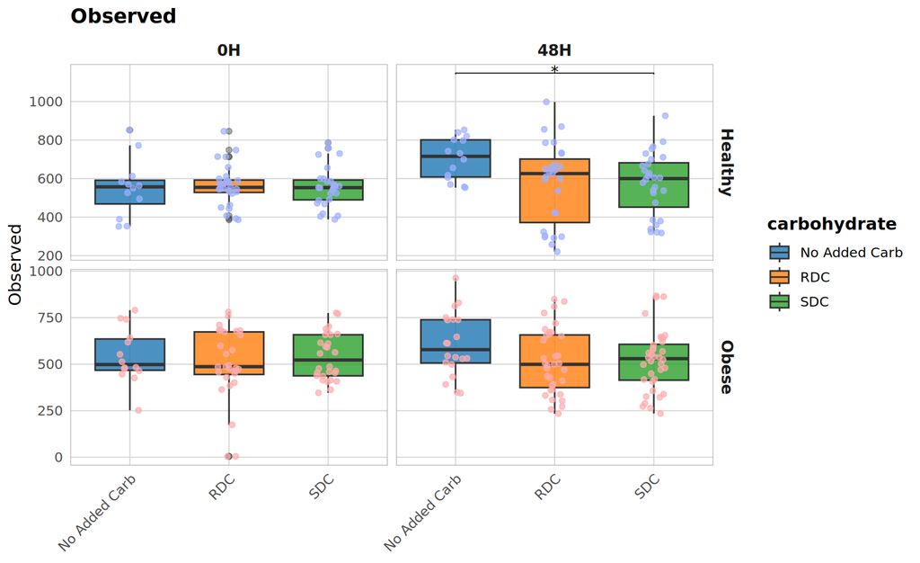

```r
alpha_plot <- function(data, metric_name, test_data) {
  # Filter data for current metric
  plot_data <- data %>%
    dplyr::filter(metric == metric_name)

  # Filter test results for current metric and remove non-significant comparisons
  test_data_metric <- test_data %>%
    dplyr::filter(metric == metric_name) %>%
    dplyr::filter(p.adj.signif != "ns")

  # Create base plot
  p <- plot_data %>%
    ggplot(aes(x = carbohydrate, y = value, fill = carbohydrate)) +
    geom_boxplot(alpha = 0.8, outlier.alpha = 0.4, width = 0.7) +
    geom_jitter(aes(color = group), width = 0.12, size = 1.5, alpha = 0.7, show.legend = FALSE) +
    scale_fill_manual(values = palette_carbohydrate) +
    scale_color_manual(values = palette_group) +
    labs(x = NULL, y = metric_name, title = metric_name) +
    facet_grid(group ~ timepoint, scales = "free_y") +
    custom_theme() +
    theme(axis.text.x = element_text(angle = 45, hjust = 1))

  # Add significance annotations only if there are significant comparisons
  if (nrow(test_data_metric) > 0) {
    p <- p +
      ggpubr::stat_pvalue_manual(
        test_data_metric,
        label = "p.adj.signif",
        tip.length = 0.005,
        bracket.nudge.y = 0.01,
        step.increase = 0.03
      )
  }

  return(p)
}

# Create plots with significance annotations
alpha_plots <- purrr::map(levels(alpha_long$metric), ~ alpha_plot(alpha_long, .x, alpha_pairwise_tests))

alpha_plots[[2]]
```

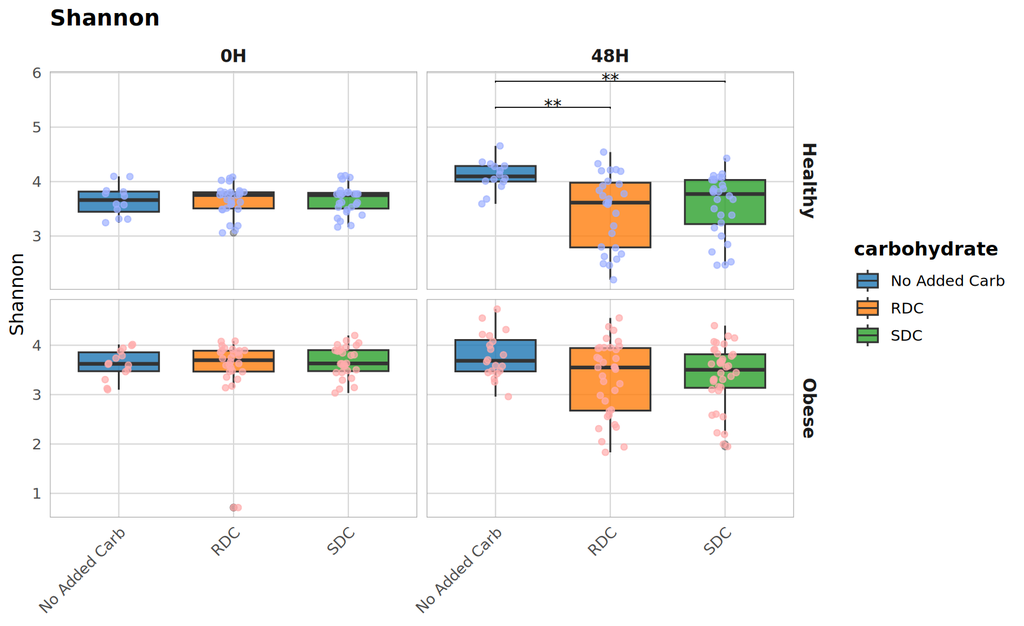

```r
alpha_plots[[1]]
```

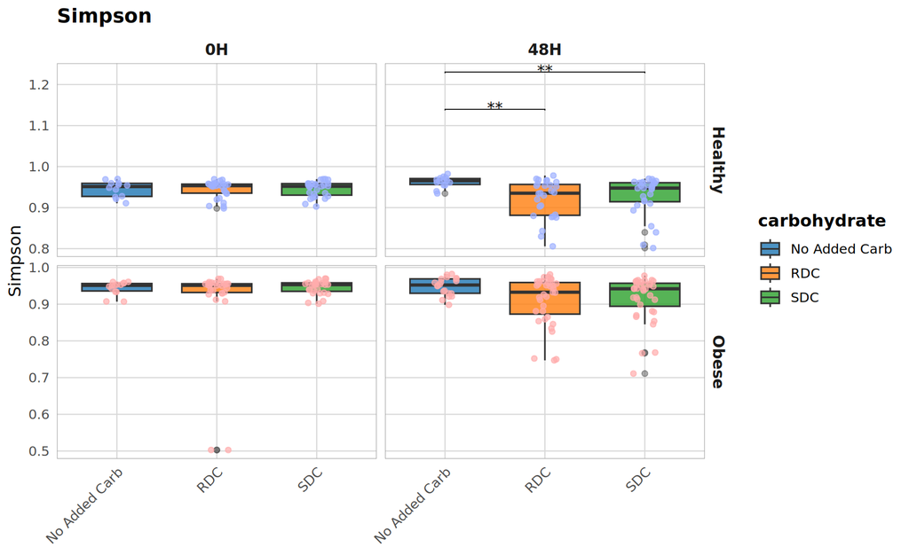

```r
alpha_plots[[3]]
```

```r
#alpha_plots[[1]] / alpha_plots[[2]] / alpha_plots[[3]] + plot_layout(guides = "collect") + plot_annotation(tag_levels = "A")
```

```r
alpha_significance %>%
  dplyr::mutate(text = glue::glue("**{metric}**: {sig_terms}")) %>%
  dplyr::pull(text) %>%
  glue::glue_collapse(sep = "\n") %>%
  cat()
```

**Shannon**: (Intercept) (q = <0.001); timepoint (q = 0.063); carbohydrate × timepoint (q = 0.037) **Observed**: (Intercept) (q = <0.001); timepoint (q = 0.030) **Simpson**: (Intercept) (q = <0.001)

### 0.4.1 4.1 Combined-Group Modeling

The limited group-level separation motivates a secondary model that collapses healthy and obese cohorts to evaluate carbohydrate effects with improved power.

```r
alpha_collapsed <- alpha_long %>%
  dplyr::mutate(group_collapsed = factor("Combined"))

alpha_models_collapsed <- alpha_collapsed %>%
  tidyr::nest(data = -metric) %>%
  dplyr::mutate(
    model = purrr::map(data, fit_alpha_model_collapsed),
    anova = purrr::map(model, ~ if (is.null(.x)) tibble::tibble() else anova_table(.x))
  )

alpha_models_collapsed %>%
  dplyr::select(metric, anova) %>%
  tidyr::unnest(anova) %>%
  gt::gt() %>%
  gt::fmt_number(columns = c(f_value), decimals = 2) %>%
  gt::fmt_number(columns = c(p_value, fdr), decimals = 3) %>%
  gt::cols_label(term = "Effect", num_df = "df num", den_df = "df den", f_value = "F", p_value = "p", fdr = "q")
```

| metric | Effect | df num | df den | F | p | q |
| --- | --- | --- | --- | --- | --- | --- |
| Observed | (Intercept) | 1 | 259 | 320.53 | 0.000 | 0.000 |
| Observed | carbohydrate | 2 | 259 | 0.35 | 0.705 | 0.705 |
| Observed | timepoint | 1 | 259 | 5.83 | 0.016 | 0.033 |
| Observed | carbohydrate:timepoint | 2 | 259 | 2.25 | 0.108 | 0.143 |
| Shannon | (Intercept) | 1 | 259 | 1,159.23 | 0.000 | 0.000 |
| Shannon | carbohydrate | 2 | 259 | 0.59 | 0.555 | 0.555 |
| Shannon | timepoint | 1 | 259 | 3.88 | 0.050 | 0.067 |
| Shannon | carbohydrate:timepoint | 2 | 259 | 4.52 | 0.012 | 0.023 |
| Simpson | (Intercept) | 1 | 259 | 7,977.41 | 0.000 | 0.000 |
| Simpson | carbohydrate | 2 | 259 | 1.55 | 0.215 | 0.286 |
| Simpson | timepoint | 1 | 259 | 0.47 | 0.492 | 0.492 |
| Simpson | carbohydrate:timepoint | 2 | 259 | 1.91 | 0.150 | 0.286 |

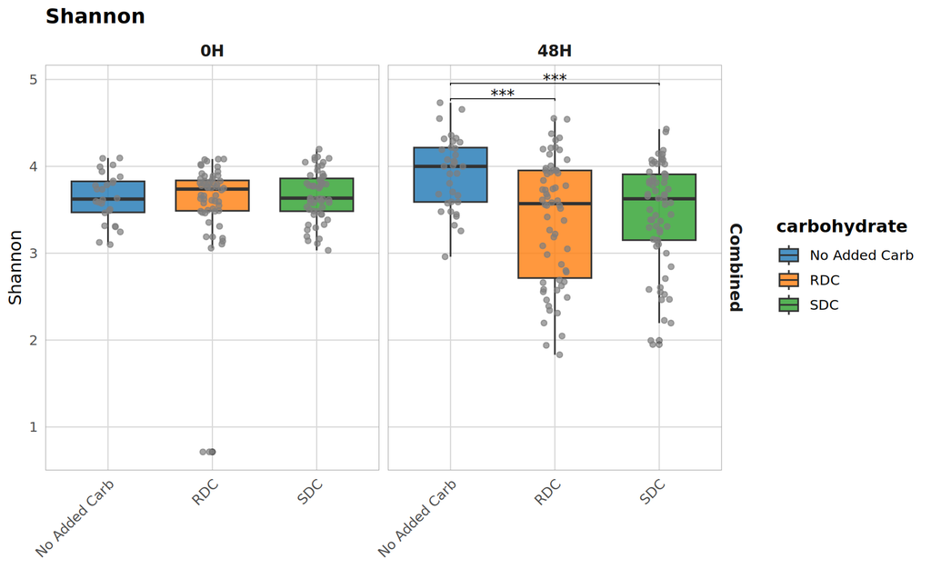

```r
# Create combined data where healthy and obese groups are merged
alpha_combined <- alpha_long %>%
  dplyr::mutate(group = "Combined") %>%
  dplyr::mutate(group = factor(group))

# Create pairwise tests for the combined data
alpha_combined_pairwise_tests <- alpha_combined %>%
  dplyr::group_by(metric, group, timepoint) %>%
  rstatix::wilcox_test(value ~ carbohydrate, p.adjust.method = "BH") %>%
  rstatix::add_significance() %>%
  rstatix::add_y_position(fun =  "max", scales = "free_y") %>%
  dplyr::ungroup()

# plot here but with the healthy and obese combined
alpha_combined_plots <- purrr::map(levels(alpha_long$metric), ~ alpha_plot(alpha_combined, .x, alpha_combined_pairwise_tests))

alpha_combined_plots[[1]]
```

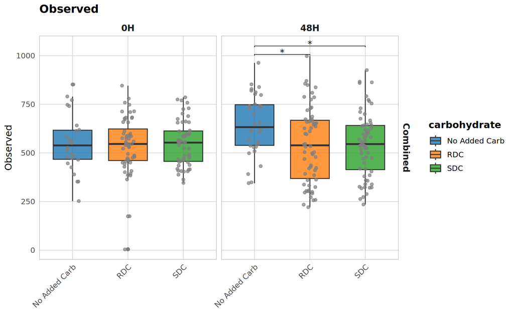

```r
alpha_combined_plots[[2]]
```

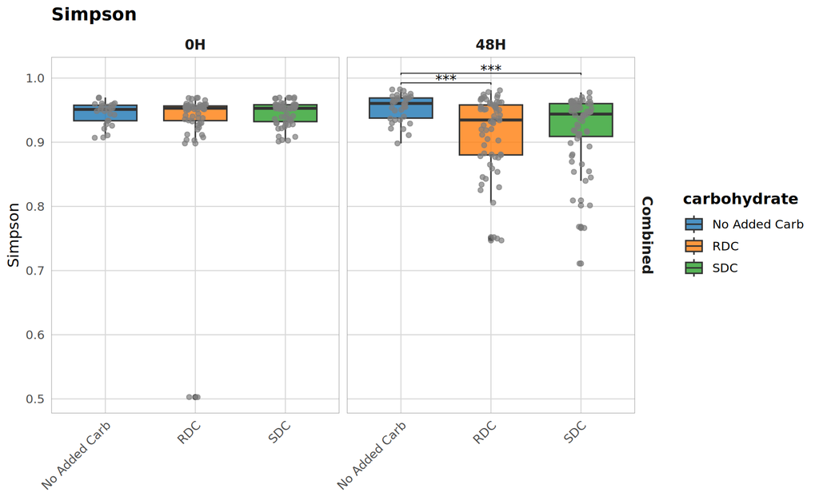

```r
alpha_combined_plots[[3]]
```

```r
alpha_collapsed_summary <- alpha_models_collapsed %>%
  dplyr::mutate(
    sig_terms = purrr::map_chr(
      anova,
      ~ {
        if (is.null(.x) || nrow(.x) == 0) {
          return("Model unavailable for this metric")
        }
        .x %>%
          dplyr::filter(fdr < 0.1) %>%
          dplyr::mutate(term = stringr::str_replace_all(term, ":", " × ")) %>%
          dplyr::mutate(label = glue::glue("{term} (q = {format_p(fdr)})")) %>%
          dplyr::pull(label) %>%
          glue::glue_collapse(sep = "; ") %>%
          {
            ifelse(. == "", "No carbohydrate × timepoint effects detected at q < 0.10", .)
          }
      }
    )
  )

alpha_collapsed_summary %>%
  dplyr::mutate(text = glue::glue("**{metric}** (groups combined): {sig_terms}")) %>%
  dplyr::pull(text) %>%
  glue::glue_collapse(sep = "\n") %>%
  cat()
```

**Observed** (groups combined): (Intercept) (q = <0.001); timepoint (q = 0.033) **Shannon** (groups combined): (Intercept) (q = <0.001); timepoint (q = 0.067); carbohydrate × timepoint (q = 0.023) **Simpson** (groups combined): (Intercept) (q = <0.001)

### 0.4.2 4.2 48 h Focus

```r
alpha_48h <- alpha_long %>% dplyr::filter(timepoint == "48H")

alpha_48_model <- alpha_48h %>%
  tidyr::nest(data = -metric) %>%
  dplyr::mutate(
    model = purrr::map(data, fit_alpha_model_48h),
    anova = purrr::map(model, ~ if (is.null(.x)) tibble::tibble() else anova_table(.x)),
    contrasts = purrr::map2(
      model,
      data,
      ~ {
        if (is.null(.x)) return(tibble::tibble())

        df_levels <- .y %>%
          dplyr::filter(!is.na(value)) %>%
          droplevels()

        group_levels <- dplyr::n_distinct(df_levels$group)
        carb_levels <- dplyr::n_distinct(df_levels$carbohydrate)

        if (group_levels > 1 && carb_levels > 1) {
          emmeans::emmeans(.x, ~ carbohydrate | group, data = df_levels) %>%
            emmeans::contrast("pairwise", adjust = "BH") %>%
            broom::tidy()
        } else if (carb_levels > 1) {
          emmeans::emmeans(.x, specs = "carbohydrate", data = df_levels) %>%
            emmeans::contrast("pairwise", adjust = "BH") %>%
            broom::tidy()
        } else if (group_levels > 1) {
          emmeans::emmeans(.x, specs = "group", data = df_levels) %>%
            emmeans::contrast("pairwise", adjust = "BH") %>%
            broom::tidy()
        } else {
          tibble::tibble()
        }
      }
    )
  )

alpha_48_model$anova
```

```
## [[1]]
## # A tibble: 4 × 6
##   term               num_df den_df f_value p_value    fdr
##   <chr>               <int>  <dbl>   <dbl>   <dbl>  <dbl>
## 1 (Intercept)             1    123 232.     0      0
## 2 group                   1     31   2.95   0.0958 0.128
## 3 carbohydrate            2    123   3.86   0.0236 0.0472
## 4 group:carbohydrate      2    123   0.280  0.756  0.756
##
## [[2]]
## # A tibble: 4 × 6
##   term               num_df den_df f_value p_value     fdr
##   <chr>               <int>  <dbl>   <dbl>   <dbl>   <dbl>
## 1 (Intercept)             1    123 619.    0       0
## 2 group                   1     31   2.42  0.130   0.173
## 3 carbohydrate            2    123   5.89  0.00362 0.00724
## 4 group:carbohydrate      2    123   0.280 0.756   0.756
##
## [[3]]
## # A tibble: 4 × 6
##   term               num_df den_df   f_value p_value    fdr
##   <chr>               <int>  <dbl>     <dbl>   <dbl>  <dbl>
## 1 (Intercept)             1    123 4757.      0      0
## 2 group                   1     31    0.733   0.398  0.531
## 3 carbohydrate            2    123    3.70    0.0275 0.0550
## 4 group:carbohydrate      2    123    0.0262  0.974  0.974
```

```r
alpha_48_text <- alpha_48_model %>%
  dplyr::mutate(
    sig_terms = purrr::map_chr(
      anova,
      ~ {
        if (is.null(.x) || nrow(.x) == 0) {
          return("Model unavailable for this metric")
        }
        .x %>%
          dplyr::filter(fdr < 0.1) %>%
          dplyr::mutate(term = stringr::str_replace_all(term, ":", " × ")) %>%
          dplyr::mutate(label = glue::glue("{term} (q = {format_p(fdr)})")) %>%
          dplyr::pull(label) %>%
          glue::glue_collapse(sep = "; ") %>%
          {
            ifelse(. == "", "No significant effects after FDR correction", .)
          }
      }
    )
  )

alpha_48_text %>%
  dplyr::mutate(text = glue::glue("**{metric}** (48 h): {sig_terms}")) %>%
  dplyr::pull(text) %>%
  glue::glue_collapse(sep = "\n") %>%
  cat()
```

**Observed** (48 h): (Intercept) (q = <0.001); carbohydrate (q = 0.047) **Shannon** (48 h): (Intercept) (q = <0.001); carbohydrate (q = 0.007) **Simpson** (48 h): (Intercept) (q = <0.001); carbohydrate (q = 0.055)

```r
# Perform pairwise Wilcoxon tests for each metric
alpha_48h_wilcoxon <- alpha_48h %>%
  group_by(metric) %>%
  wilcox_test(value ~ carbohydrate, p.adjust.method = "BH") %>%
  add_significance()

# Calculate max values for each metric to position annotations
max_values <- alpha_48h %>%
  group_by(metric) %>%
  summarise(max_val = max(value, na.rm = TRUE), .groups = "drop")

# Add manual y-positions based on data range for each metric
alpha_48h_wilcoxon <- alpha_48h_wilcoxon %>%
  left_join(max_values, by = "metric") %>%
  group_by(metric) %>%
  mutate(
    y.position = case_when(
      metric == "Shannon" ~ max_val * 1.1,
      metric == "Observed" ~ max_val * 1.15,
      metric == "Simpson" ~ max_val * 1.1
    ),
    y.position = y.position + (row_number() - 1) * (max_val * 0.1)
  ) %>%
  ungroup()

# Check the structure of the results
print("Columns in alpha_48h_wilcoxon:")
```

```
## [1] "Columns in alpha_48h_wilcoxon:"
```

```r
print(names(alpha_48h_wilcoxon))
```

```
##  [1] "metric"       ".y."          "group1"       "group2"       "n1"           "n2"           "statistic"    "p"            "p.adj"        "p.adj.signif"
## [11] "max_val"      "y.position"
```

```r
print("First few rows:")
```

```
## [1] "First few rows:"
```

```r
print(head(alpha_48h_wilcoxon))
```

```
## # A tibble: 6 × 12
##   metric   .y.   group1        group2    n1    n2 statistic        p    p.adj p.adj.signif max_val y.position
##   <fct>    <chr> <chr>         <chr>  <int> <int>     <dbl>    <dbl>    <dbl> <chr>          <dbl>      <dbl>
## 1 Shannon  value No Added Carb RDC       34    62     1500  0.000643 0.000965 ***             4.73       5.21
## 2 Shannon  value No Added Carb SDC       34    64     1563  0.000398 0.000965 ***             4.73       5.68
## 3 Shannon  value RDC           SDC       62    64     1911  0.723    0.723    ns              4.73       6.15
## 4 Observed value No Added Carb RDC       34    62     1396  0.009    0.013    *             998       1148.
## 5 Observed value No Added Carb SDC       34    64     1466. 0.005    0.013    *             998       1247.
## 6 Observed value RDC           SDC       62    64     1980  0.986    0.986    ns            998       1347.
```

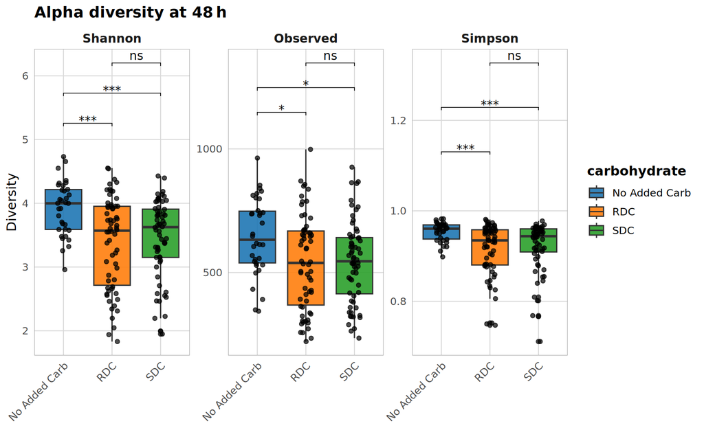

```r
alpha_48h %>%
  ggplot(aes(x = carbohydrate, y = value, fill = carbohydrate)) +
  #geom_violin(trim = FALSE, alpha = 0.8) +
  geom_boxplot(alpha = 0.9) +
  geom_jitter(width = 0.12, size = 1.5, alpha = 0.7, show.legend = FALSE) +
  stat_pvalue_manual(alpha_48h_wilcoxon,
                     label = "p.adj.signif",
                     tip.length = 0.01,
                     bracket.nudge.y = 0.05) +
  facet_wrap(~ metric, scales = "free_y") +
  scale_fill_manual(values = palette_carbohydrate) +
  labs(x = NULL, y = "Diversity", title = "Alpha diversity at 48 h") +
  custom_theme() +
  theme(axis.text.x = element_text(angle = 45, hjust = 1))
```

## 0.5 5. Beta Diversity and Community Structure

```r
make_pcoa_df <- function(ps_obj, distance_method) {
  ord <- ordinate(ps_obj, method = "PCoA", distance = distance_method)
  vecs <- as_tibble(ord$vectors[, 1:2], rownames = "SampleID")
  colnames(vecs)[2:3] <- c("PC1", "PC2")
  vecs <- vecs %>%
    dplyr::mutate(
      axis1_var = ord$values$Relative_eig[1],
      axis2_var = ord$values$Relative_eig[2]
    ) %>%
    dplyr::left_join(as_tibble(metadata, .name_repair = "minimal"), by = "SampleID")
  vecs$distance_method <- distance_method
  vecs
}

dist_methods <- c("bray", "jaccard")

pcoa_dfs <- purrr::map_dfr(dist_methods, ~ make_pcoa_df(ps_rel, .x))
```

```r
permanova_results_raw <- purrr::map_dfr(
  dist_methods,
  ~ {
    dist_mat <- phyloseq::distance(ps_rel, method = .x)
    df <- as(sample_data(ps_rel), "data.frame")
    adonis_out <- vegan::adonis2(
      dist_mat ~ group * carbohydrate + timepoint,
      data = df,
      permutations = 999,
      strata = df$subject_id
    )
    adonis_tbl <- as.data.frame(adonis_out) %>% rownames_to_column('term') %>% janitor::clean_names()
    adonis_tbl$distance <- .x
    adonis_tbl
  }
)

permanova_p_col <- intersect(c("pr_greater_f_", "pr_greater_f", "pr_f", "p_value"), names(permanova_results_raw))
permanova_f_col <- intersect(c("f", "f_model", "pseudo_f"), names(permanova_results_raw))
permanova_r2_col <- intersect(c("r2", "r_squared", "r2_adj"), names(permanova_results_raw))

if (length(permanova_p_col) == 0 || length(permanova_f_col) == 0 || length(permanova_r2_col) == 0) {
  stop(glue::glue(
    "Unexpected PERMANOVA columns. Available: {glue::glue_collapse(names(permanova_results_raw), sep = ', ')}"
  ))
}

permanova_results <- permanova_results_raw %>%
  dplyr::mutate(
    f = .data[[permanova_f_col[1]]],
    r2 = .data[[permanova_r2_col[1]]],
    p_value = .data[[permanova_p_col[1]]],
    q_value = fdr_adjust(p_value)
  )

permanova_results %>%
  gt::gt() %>%
  gt::fmt_number(columns = c(f, r2), decimals = 3) %>%
  gt::fmt_number(columns = c(p_value, q_value), decimals = 3) %>%
  gt::cols_label(term = "Effect", f = "F", r2 = "R2", p_value = "p", q_value = "q") %>%
  gt::tab_header("PERMANOVA results (subject-level strata)")
```

PERMANOVA results (subject-level strata)

| Effect | df | sum_of_sqs | R2 | F | pr_f | distance | p | q |
| --- | --- | --- | --- | --- | --- | --- | --- | --- |
| Model | 6 | 15.61856 | 0.226 | 14.074 | 0.001 | bray | 0.001 | 0.001 |
| Residual | 290 | 53.63882 | 0.774 | NA | NA | bray | NA | NA |
| Total | 296 | 69.25738 | 1.000 | NA | NA | bray | NA | NA |
| Model | 6 | 15.45973 | 0.165 | 9.573 | 0.001 | jaccard | 0.001 | 0.001 |
| Residual | 290 | 78.05599 | 0.835 | NA | NA | jaccard | NA | NA |
| Total | 296 | 93.51572 | 1.000 | NA | NA | jaccard | NA | NA |

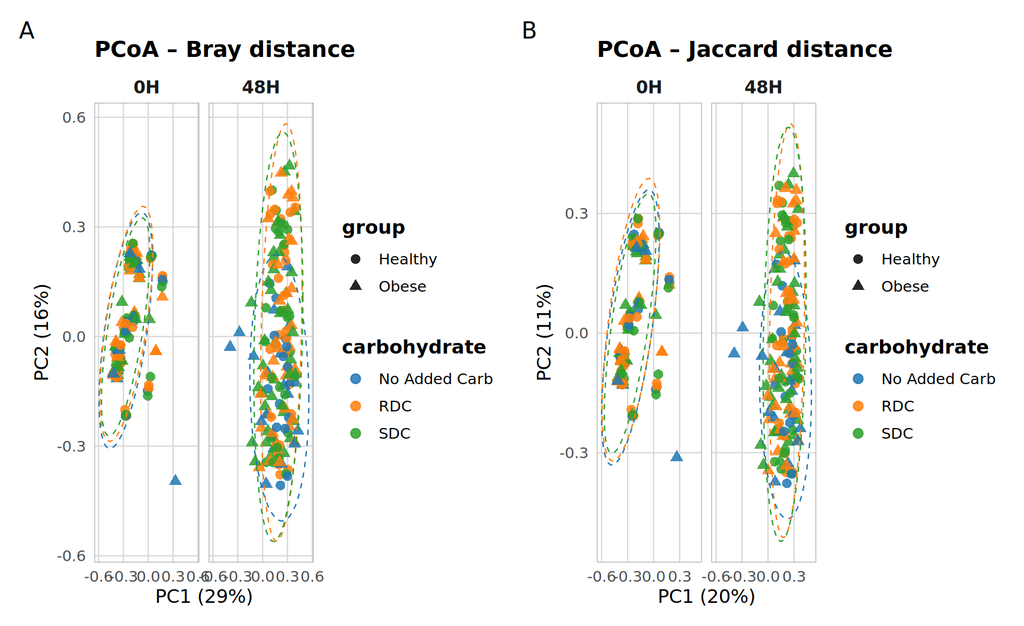

```r
pcoa_plot <- function(df, method_name) {
  df_subset <- df %>% dplyr::filter(distance_method == method_name)
  var1 <- scales::percent(round(df_subset$axis1_var[1], 3))
  var2 <- scales::percent(round(df_subset$axis2_var[1], 3))

  # Get PERMANOVA results for this distance method - use group:carbohydrate interaction
  permanova_subset <- permanova_results %>%
    dplyr::filter(distance == method_name, term == "group:carbohydrate")

  # Create annotation text and position
  if (nrow(permanova_subset) > 0) {
    r2_val <- round(permanova_subset$r2[1], 3)
    p_val <- round(permanova_subset$p_value[1], 3)
    annotation_text <- glue::glue("R² = {r2_val}, p = {p_val}")

    # Calculate per-facet label positions, guard against missing/flat ranges
    annotation_df <- df_subset %>%
      dplyr::filter(!is.na(PC1), !is.na(PC2)) %>%
      dplyr::group_by(timepoint) %>%
      dplyr::summarise(
        x_min = min(PC1),
        x_max = max(PC1),
        y_min = min(PC2),
        y_max = max(PC2),
        .groups = "drop"
      ) %>%
      dplyr::mutate(
        x_span = x_max - x_min,
        y_span = y_max - y_min,
        PC1 = ifelse(is.finite(x_span) & x_span > 0, x_min + 0.05 * x_span, x_min),
        PC2 = ifelse(is.finite(y_span) & y_span > 0, y_max - 0.05 * y_span, y_max),
        label = annotation_text
      ) %>%
      dplyr::select(timepoint, PC1, PC2, label)
  } else {
    annotation_df <- data.frame(
      PC1 = numeric(0),
      PC2 = numeric(0),
      label = character(0),
      timepoint = character(0)
    )
  }

  p <- ggplot(df_subset, aes(x = PC1, y = PC2, color = carbohydrate, shape = group)) +
    geom_point(size = 2.5, alpha = 0.85) +
    stat_ellipse(aes(group = interaction(carbohydrate, timepoint), color = carbohydrate),
      linewidth = 0.4, linetype = "dashed", show.legend = FALSE
    ) +
    facet_wrap(~timepoint) +
    scale_color_manual(values = palette_carbohydrate) +
    scale_shape_manual(values = c(16, 17)) +
    labs(
      x = glue::glue("PC1 ({var1})"),
      y = glue::glue("PC2 ({var2})"),
      title = glue::glue("PCoA – {stringr::str_to_title(method_name)} distance")
    ) +
    custom_theme()

  if (nrow(annotation_df) > 0) {
    p <- p + geom_label(
      data = annotation_df,
      aes(x = PC1, y = PC2, label = label),
      hjust = 0, vjust = 1, size = 3, fontface = "bold",
      inherit.aes = FALSE, fill = "white", alpha = 0.8
    )
  }

  p
}

(pcoa_plot(pcoa_dfs, "bray") | pcoa_plot(pcoa_dfs, "jaccard")) + plot_annotation(tag_levels = "A")
```

```r
betadisp_results <- purrr::map_dfr(
  dist_methods,
  ~ {
    dist_mat <- phyloseq::distance(ps_rel, method = .x)
    df <- as(sample_data(ps_rel), "data.frame")
    bd <- vegan::betadisper(dist_mat, df$carbohydrate)
    perm <- vegan::permutest(bd, permutations = 999)

    # Extract values more robustly
    perm_df <- as.data.frame(perm$tab)
    f_row <- which(rownames(perm_df) %in% c("F", "Groups"))

    tibble(
      distance = .x,
      stat = perm_df[f_row[1], "F"],
      p_value = perm_df[f_row[1], "Pr(>F)"]
    )
  }
) %>%
  dplyr::mutate(q_value = fdr_adjust(p_value))

betadisp_results %>%
  gt::gt() %>%
  gt::fmt_number(columns = c(stat, p_value, q_value), decimals = 3) %>%
  gt::cols_label(stat = "F", p_value = "p", q_value = "q") %>%
  gt::tab_header("Homogeneity of dispersion (carbohydrate groups)")
```

Homogeneity of dispersion (carbohydrate groups)

| distance | F | p | q |
| --- | --- | --- | --- |
| bray | 0.962 | 0.368 | 0.469 |
| jaccard | 0.769 | 0.469 | 0.469 |

### 0.5.1 Interpretation

```r
permanova_summary <- permanova_results %>%
  dplyr::mutate(q = fdr_adjust(p_value)) %>%
  dplyr::filter(term != "Residual" & q < 0.1) %>%
  dplyr::mutate(item = glue::glue("{stringr::str_to_title(distance)}: {term} (q = {format_p(q)})")) %>%
  dplyr::pull(item)

if (length(permanova_summary) == 0) {
  cat("No beta-diversity terms reach q < 0.10 after FDR adjustment. Patterns are primarily driven by subject-level variability.")
} else {
  cat(glue::glue_collapse(permanova_summary, sep = "\n"))
}
```

Bray: Model (q = 0.001) Jaccard: Model (q = 0.001)

### 0.5.2 5.1 Beta Diversity at 48 h

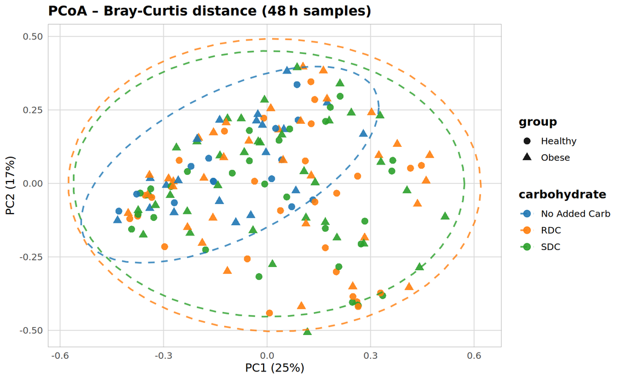

```r
ps_48h <- phyloseq::subset_samples(ps_rel, Timepoint == "48H")

pcoa_48h <- make_pcoa_df(ps_48h, "bray")

pcoa_48h %>%
  ggplot(aes(x = PC1, y = PC2, color = carbohydrate, shape = group)) +
  geom_point(size = 3, alpha = 0.9) +
  stat_ellipse(aes(group = carbohydrate, color = carbohydrate), linewidth = 0.8, linetype = "dashed", alpha = 0.8) +
  scale_color_manual(values = palette_carbohydrate) +
  scale_shape_manual(values = c(16, 17)) +
  labs(
    x = glue::glue("PC1 ({scales::percent(round(pcoa_48h$axis1_var[1], 3))})"),
    y = glue::glue("PC2 ({scales::percent(round(pcoa_48h$axis2_var[1], 3))})"),
    title = "PCoA – Bray-Curtis distance (48 h samples)"
  ) +
  custom_theme()
```

```r
metadata_48h <- as(sample_data(ps_48h), "data.frame")
permanova_48h <- vegan::adonis2(
  phyloseq::distance(ps_48h, method = "bray") ~ group * carbohydrate,
  data = metadata_48h,
  permutations = 999,
  strata = metadata_48h$subject_id
)

permanova_48h_tbl <- as.data.frame(permanova_48h) %>% rownames_to_column('term') %>% janitor::clean_names()

# Find the correct column names for p-value, F-statistic, and R-squared
permanova_48h_p_col <- intersect(c("pr_greater_f_", "pr_greater_f", "pr_f", "p_value"), names(permanova_48h_tbl))
permanova_48h_f_col <- intersect(c("f", "f_model", "pseudo_f"), names(permanova_48h_tbl))
permanova_48h_r2_col <- intersect(c("r2", "r_squared", "r2_adj"), names(permanova_48h_tbl))

permanova_48h_tbl %>%
  dplyr::mutate(p_value = !!sym(permanova_48h_p_col), q = fdr_adjust(p_value)) %>%
  gt::gt() %>%
  gt::fmt_number(columns = c(!!sym(permanova_48h_f_col), !!sym(permanova_48h_r2_col)), decimals = 3) %>%
  gt::fmt_number(columns = c(p_value, q), decimals = 3) %>%
  gt::cols_label(term = "Effect", !!sym(permanova_48h_f_col) := "F", !!sym(permanova_48h_r2_col) := "R2", p_value = "p", q = "q")
```

| Effect | df | sum_of_sqs | R2 | F | pr_f | p | q |
| --- | --- | --- | --- | --- | --- | --- | --- |
| Model | 5 | 1.905181 | 0.052 | 1.684 | 0.001 | 0.001 | 0.001 |
| Residual | 154 | 34.841383 | 0.948 | NA | NA | NA | NA |
| Total | 159 | 36.746564 | 1.000 | NA | NA | NA | NA |

## 0.6 6. Baseline Clustering and Trajectories

```r
ps_0h <- phyloseq::subset_samples(ps_rel, Timepoint == "0H")
stopifnot(nsamples(ps_0h) > 0)

bray_0h <- phyloseq::distance(ps_0h, method = "bray")
dist_matrix <- as.matrix(bray_0h)

silhouette_scores <- map_dbl(2:6, ~ {
  pam_fit <- cluster::pam(bray_0h, k = .x)
  mean(cluster::silhouette(pam_fit)[, "sil_width"])
})

best_k <- which.max(silhouette_scores) + 1
pam_best <- cluster::pam(bray_0h, k = best_k)

cluster_assignments <- tibble(
  SampleID = sample_names(ps_0h),
  baseline_cluster = factor(paste0("Cluster", pam_best$clustering), levels = paste0("Cluster", seq_len(best_k)))
)

cluster_summary <- cluster_assignments %>%
  dplyr::left_join(as_tibble(metadata, .name_repair = "minimal"), by = "SampleID") %>%
  dplyr::count(baseline_cluster, carbohydrate, group, name = "n")

cluster_summary
```

| baseline_cluster | carbohydrate | group | n |
| --- | --- | --- | --- |
| Cluster1 | No Added Carb | Healthy | 2 |
| Cluster1 | No Added Carb | Obese | 2 |
| Cluster1 | RDC | Healthy | 3 |
| Cluster1 | RDC | Obese | 5 |
| Cluster1 | SDC | Healthy | 4 |
| Cluster1 | SDC | Obese | 4 |
| Cluster2 | No Added Carb | Healthy | 3 |
| Cluster2 | No Added Carb | Obese | 2 |
| Cluster2 | RDC | Healthy | 1 |
| Cluster2 | RDC | Obese | 8 |

[output cut: 23 more lines]

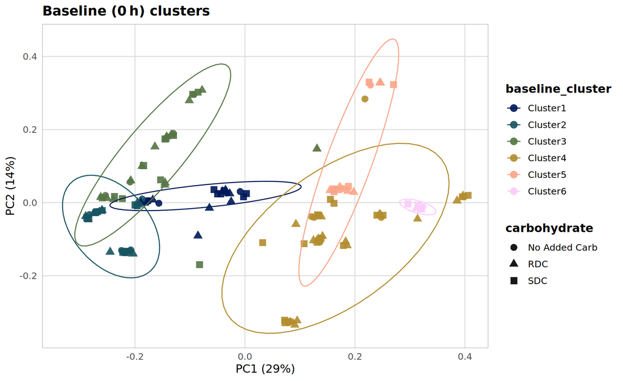

```r
cluster_ord <- make_pcoa_df(ps_0h, "bray") %>%
  dplyr::left_join(cluster_assignments, by = "SampleID")

cluster_ord %>%
  ggplot(aes(x = PC1, y = PC2, color = baseline_cluster, shape = carbohydrate)) +
  geom_point(size = 3, alpha = 0.9) +
  stat_ellipse(aes(group = baseline_cluster), linewidth = 0.5) +
  scale_color_manual(values = palette_cluster) +
  labs(
    title = "Baseline (0 h) clusters",
    x = glue::glue("PC1 ({scales::percent(round(cluster_ord$axis1_var[1], 3))})"),
    y = glue::glue("PC2 ({scales::percent(round(cluster_ord$axis2_var[1], 3))})")
  ) +
  custom_theme()
```

```r
metadata_with_cluster <- metadata %>%
  dplyr::left_join(cluster_assignments %>% dplyr::select(SampleID, baseline_cluster), by = "SampleID")

# propagate baseline cluster to all timepoints via subject_id
subject_clusters <- cluster_assignments %>%
  dplyr::left_join(metadata %>% dplyr::select(SampleID, subject_id), by = "SampleID") %>%
  dplyr::group_by(subject_id) %>%
  dplyr::summarise(baseline_cluster = dplyr::first(baseline_cluster), .groups = "drop")

metadata_with_cluster <- metadata %>%
  dplyr::left_join(subject_clusters, by = "subject_id")

ps_with_cluster <- ps_rel
sample_data(ps_with_cluster)$baseline_cluster <- metadata_with_cluster$baseline_cluster[match(sample_names(ps_with_cluster), metadata_with_cluster$SampleID)]
```

```r
# Only include subjects that have baseline cluster assignments
subjects_with_clusters <- subject_clusters$subject_id
ps_48h_cluster <- phyloseq::subset_samples(ps_with_cluster, Timepoint == "48H" & subject_id %in% subjects_with_clusters)

# Check how many samples we have after filtering
cat("48H samples with baseline cluster assignments:", nsamples(ps_48h_cluster), "\n")
```

```
## 48H samples with baseline cluster assignments: 140
```

```r
cat("Total 48H samples:", sum(sample_data(ps_with_cluster)$Timepoint == "48H"), "\n")
```

```
## Total 48H samples: 160
```

```r
# Show which subjects are missing baseline samples
all_48h_subjects <- as(sample_data(ps_with_cluster), "data.frame") %>%
  dplyr::filter(Timepoint == "48H") %>%
  dplyr::pull(subject_id) %>%
  unique()

missing_baseline_subjects <- setdiff(all_48h_subjects, subjects_with_clusters)
if(length(missing_baseline_subjects) > 0) {
  cat("Subjects missing baseline (0H) samples:", paste(missing_baseline_subjects, collapse = ", "), "\n")
  cat("These subjects will be excluded from cluster-based 48H analysis.\n")
} else {
  cat("All 48H subjects have baseline cluster assignments.\n")
}
```

```
## Subjects missing baseline (0H) samples: 276B, 123B, 276A, 116B
## These subjects will be excluded from cluster-based 48H analysis.
```

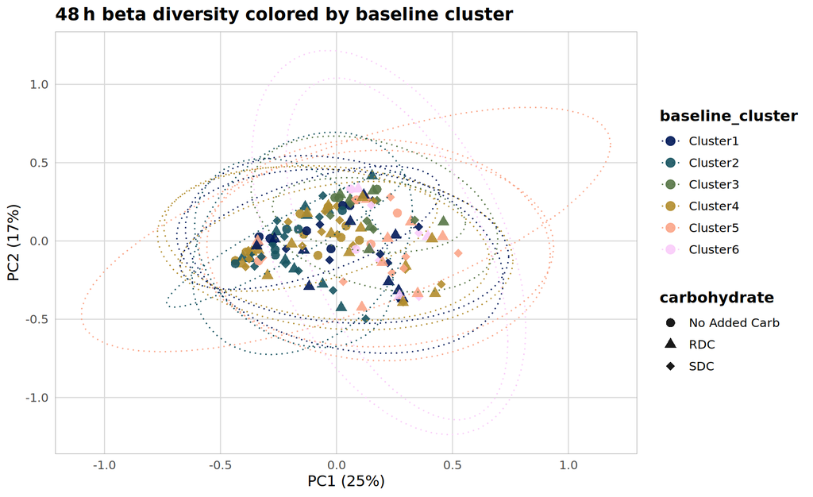

```r
ord_48h_cluster <- make_pcoa_df(ps_48h_cluster, "bray") %>%
  dplyr::mutate(baseline_cluster = sample_data(ps_48h_cluster)$baseline_cluster[match(SampleID, sample_names(ps_48h_cluster))])

# Create dynamic color palette based on actual clusters present
actual_clusters <- levels(factor(ord_48h_cluster$baseline_cluster))
cluster_palette_dynamic <- setNames(scico::scico(length(actual_clusters), palette = "batlow"), actual_clusters)

ord_48h_cluster %>%
  ggplot(aes(x = PC1, y = PC2, color = baseline_cluster, shape = carbohydrate)) +
  geom_point(size = 3, alpha = 0.9) +
  stat_ellipse(aes(group = interaction(baseline_cluster, carbohydrate)),
               linewidth = 0.5, linetype = "dotted",
               level = 0.95, type = "norm") +
  scale_color_manual(values = cluster_palette_dynamic) +
  scale_shape_manual(values = c(16, 17, 18)) +
  labs(
    title = "48 h beta diversity colored by baseline cluster",
    x = glue::glue("PC1 ({scales::percent(round(ord_48h_cluster$axis1_var[1], 3))})"),
    y = glue::glue("PC2 ({scales::percent(round(ord_48h_cluster$axis2_var[1], 3))})")
  ) +
  custom_theme()
```

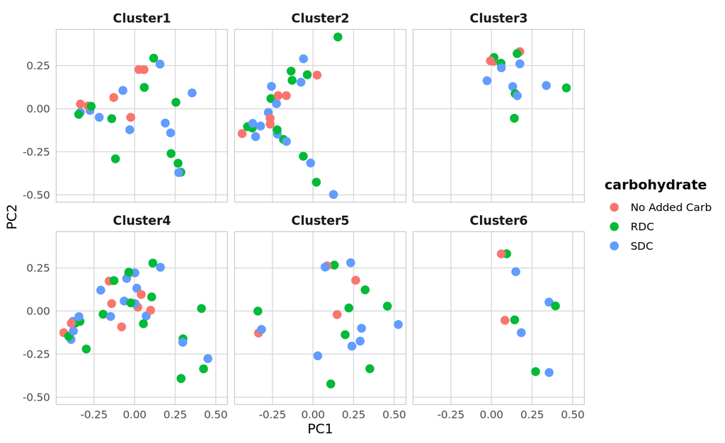

```r
ord_48h_cluster %>% ggplot(aes(PC1, PC2)) +
  geom_point(aes(color = carbohydrate), size = 3) +
  facet_wrap(~baseline_cluster)
```

```r
cluster_response <- ord_48h_cluster %>%
  dplyr::filter(!is.na(baseline_cluster)) %>%
  dplyr::group_by(baseline_cluster, carbohydrate) %>%
  dplyr::summarise(
    mean_PC1 = mean(PC1),
    mean_PC2 = mean(PC2),
    n = n(),
    .groups = "drop"
  )

cluster_response
```

| baseline_cluster | carbohydrate | mean_PC1 | mean_PC2 | n |
| --- | --- | --- | --- | --- |
| Cluster1 | No Added Carb | -0.114517815 | 0.08492234 | 6 |
| Cluster1 | RDC | 0.034072785 | -0.08617105 | 10 |
| Cluster1 | SDC | 0.026746202 | -0.03437520 | 10 |
| Cluster2 | No Added Carb | -0.219618441 | 0.00916228 | 6 |
| Cluster2 | RDC | -0.147600646 | -0.01528082 | 11 |
| Cluster2 | SDC | -0.184029437 | -0.07669040 | 12 |
| Cluster3 | No Added Carb | 0.059784726 | 0.29386053 | 3 |
| Cluster3 | RDC | 0.163362707 | 0.17188848 | 6 |
| Cluster3 | SDC | 0.139339752 | 0.16603020 | 6 |
| Cluster4 | No Added Carb | -0.119899264 | 0.02973588 | 9 |

[output cut: 8 more lines]

```r
ps_48h_counts <- phyloseq::subset_samples(ps, Timepoint == "48H")
alpha_48h_cluster <- estimate_richness(ps_48h_counts, measures = c("Observed", "Shannon", "Simpson")) %>%
  rownames_to_column("SampleID") %>%
  pivot_longer(-SampleID, names_to = "metric", values_to = "value") %>%
  dplyr::left_join(metadata_with_cluster, by = "SampleID") %>%
  dplyr::filter(!is.na(baseline_cluster))

cluster_models <- alpha_48h_cluster %>%
  tidyr::nest(data = -metric) %>%
  dplyr::mutate(
    model = purrr::map(data, fit_cluster_model),
    anova = purrr::map(model, ~ if (is.null(.x)) tibble::tibble() else anova_table(.x))
  )

cluster_models %>%
  dplyr::select(metric, anova) %>%
  tidyr::unnest(anova) %>%
  gt::gt() %>%
  gt::fmt_number(columns = c(f_value), decimals = 3) %>%
  gt::fmt_number(columns = c(p_value, fdr), decimals = 3) %>%
  gt::cols_label(term = "Effect", num_df = "df num", den_df = "df den", f_value = "F", p_value = "p", fdr = "q")
```

| metric | Effect | df num | df den | F | p | q |
| --- | --- | --- | --- | --- | --- | --- |
| Observed | (Intercept) | 1 | 99 | 112.467 | 0.000 | 0.000 |
| Observed | baseline_cluster | 5 | 23 | 0.842 | 0.534 | 0.712 |
| Observed | carbohydrate | 2 | 99 | 2.504 | 0.087 | 0.174 |
| Observed | baseline_cluster:carbohydrate | 10 | 99 | 0.552 | 0.849 | 0.849 |
| Shannon | (Intercept) | 1 | 99 | 280.431 | 0.000 | 0.000 |
| Shannon | baseline_cluster | 5 | 23 | 0.419 | 0.830 | 0.981 |
| Shannon | carbohydrate | 2 | 99 | 3.713 | 0.028 | 0.056 |
| Shannon | baseline_cluster:carbohydrate | 10 | 99 | 0.296 | 0.981 | 0.981 |
| Simpson | (Intercept) | 1 | 99 | 2,625.468 | 0.000 | 0.000 |
| Simpson | baseline_cluster | 5 | 23 | 0.240 | 0.940 | 0.981 |
| Simpson | carbohydrate | 2 | 99 | 2.824 | 0.064 | 0.128 |
| Simpson | baseline_cluster:carbohydrate | 10 | 99 | 0.295 | 0.981 | 0.981 |

```r
cluster_text <- cluster_models %>%
  dplyr::mutate(summary = purrr::map_chr(
    anova,
    ~ {
      if (is.null(.x) || nrow(.x) == 0) {
        return("Model unavailable for this metric at 48 h")
      }
      .x %>%
        dplyr::filter(fdr < 0.1) %>%
        dplyr::mutate(label = glue::glue("{term} (q = {format_p(fdr)})")) %>%
        dplyr::pull(label) %>%
        glue::glue_collapse(sep = "; ") %>%
        {ifelse(. == "", "No significant cluster–carbohydrate interactions detected at 48 h", .)}
    }
  ))

cluster_text %>%
  dplyr::mutate(text = glue::glue("**{metric}**: {summary}")) %>%
  dplyr::pull(text) %>%
  glue::glue_collapse(sep = "\n") %>%
  cat()
```

**Observed**: (Intercept) (q = <0.001) **Shannon**: (Intercept) (q = <0.001); carbohydrate (q = 0.056) **Simpson**: (Intercept) (q = <0.001)

## 0.7 7. Community Composition Profiles

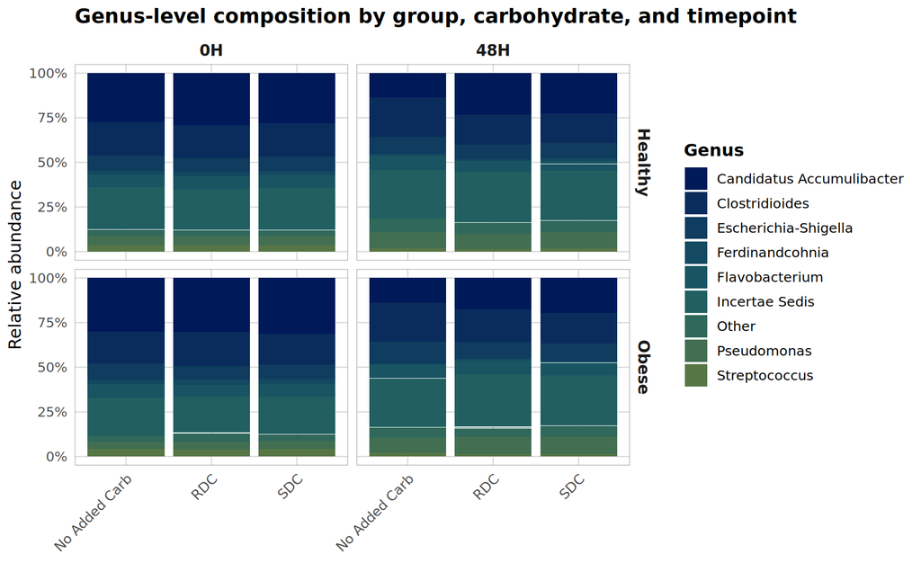

```r
ps_genus <- collapse_taxa(ps_with_cluster, rank = "Genus", top_n = 20)

ggplot(psmelt(microbiome::transform(ps_genus, "compositional")),
       aes(x = carbohydrate, y = Abundance, fill = Genus)) +
  geom_col(position = "fill") +
  facet_grid(group ~ timepoint) +
  scale_y_continuous(labels = scales::percent) +
  scale_fill_manual(values = scico::scico(21, palette = "batlow")) +
  labs(
    x = NULL,
    y = "Relative abundance",
    title = "Genus-level composition by group, carbohydrate, and timepoint"
  ) +
  custom_theme() +
  theme(axis.text.x = element_text(angle = 45, hjust = 1))
```

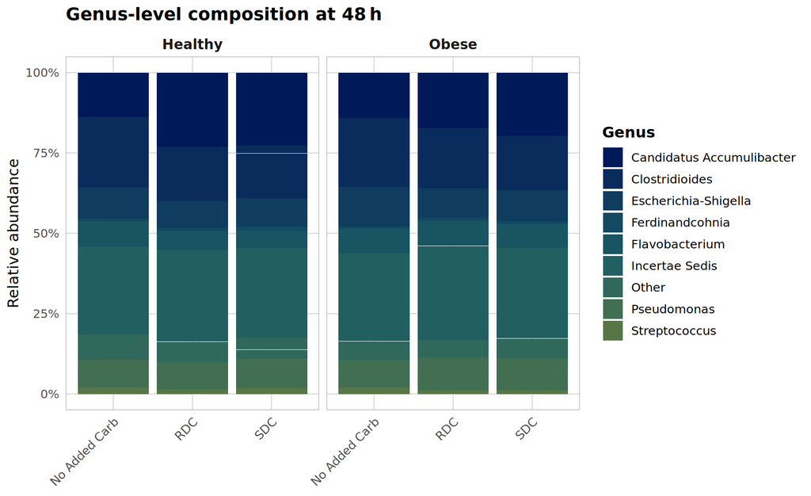

```r
ps_48h_genus <- phyloseq::subset_samples(ps_genus, Timepoint == "48H")

ggplot(psmelt(microbiome::transform(ps_48h_genus, "compositional")),
       aes(x = carbohydrate, y = Abundance, fill = Genus)) +
  geom_col(position = "fill") +
  facet_wrap(~ group) +
  scale_y_continuous(labels = scales::percent) +
  scale_fill_manual(values = scico::scico(21, palette = "batlow")) +
  labs(
    x = NULL,
    y = "Relative abundance",
    title = "Genus-level composition at 48 h"
  ) +
  custom_theme() +
  theme(axis.text.x = element_text(angle = 45, hjust = 1))
```

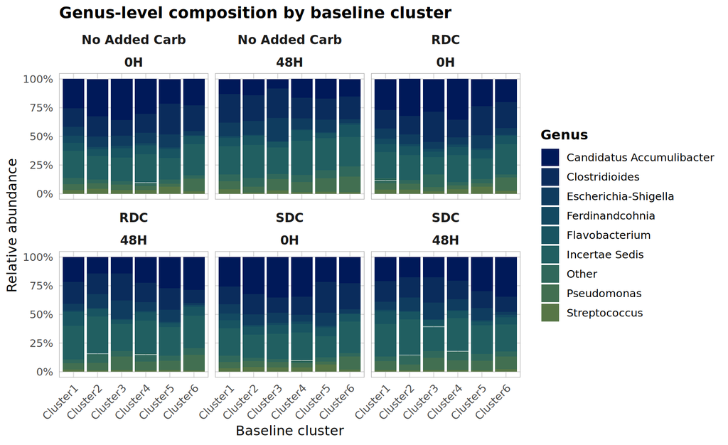

```r
ps_cluster <- phyloseq::subset_samples(ps_genus, !is.na(sample_data(ps_genus)$baseline_cluster))

ggplot(psmelt(microbiome::transform(ps_cluster, "compositional")),
       aes(x = baseline_cluster, y = Abundance, fill = Genus)) +
  geom_col(position = "fill") +
  facet_wrap(~ carbohydrate + timepoint, ncol = 3) +
  scale_y_continuous(labels = scales::percent) +
  scale_fill_manual(values = scico::scico(21, palette = "batlow")) +
  labs(
    x = "Baseline cluster",
    y = "Relative abundance",
    title = "Genus-level composition by baseline cluster"
  ) +
  custom_theme() +
  theme(axis.text.x = element_text(angle = 45, hjust = 1))
```

## 0.8 Alluvial flow diagrams: Genus abundance changes from 0H to 48H

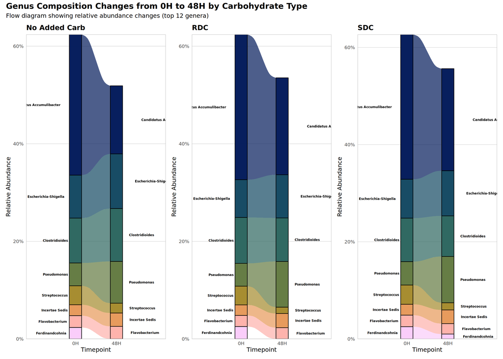

```r
# Install ggalluvial if not available
if (!requireNamespace("ggalluvial", quietly = TRUE)) {
  install.packages("ggalluvial")
}
library(ggalluvial)

# Prepare data for alluvial diagrams
ps_genus_rel <- transform_sample_counts(ps_genus, function(x) x / sum(x))

# Extract data
otu_mat <- as.matrix(otu_table(ps_genus_rel))
if (!taxa_are_rows(ps_genus_rel)) {
  otu_mat <- t(otu_mat)
}

tax_df <- as.data.frame(tax_table(ps_genus_rel))
meta_df <- data.frame(sample_data(ps_genus_rel))

# Create long format data
alluvial_data <- otu_mat %>%
  as.data.frame() %>%
  tibble::rownames_to_column("ASV") %>%
  tidyr::pivot_longer(-ASV, names_to = "SampleID", values_to = "Abundance") %>%
  dplyr::left_join(
    tax_df %>% tibble::rownames_to_column("ASV") %>% dplyr::select(ASV, Genus),
    by = "ASV"
  ) %>%
  dplyr::left_join(
    meta_df %>% tibble::rownames_to_column("SampleID") %>%
      dplyr::select(SampleID, Timepoint, Carbohydrate),
    by = "SampleID"
  ) %>%
  dplyr::group_by(Genus, Timepoint, Carbohydrate) %>%
  dplyr::summarise(mean_abundance = mean(Abundance), .groups = "drop") %>%
  dplyr::filter(mean_abundance > 0.01)  # Keep genera >1%

# Get top genera
top_genera <- alluvial_data %>%
  dplyr::group_by(Genus) %>%
  dplyr::summarise(max_abund = max(mean_abundance)) %>%
  dplyr::arrange(desc(max_abund)) %>%
  head(12) %>%
  pull(Genus)

# Filter to top genera and add "Other" category
alluvial_plot_data <- alluvial_data %>%
  dplyr::mutate(
    Genus_grouped = ifelse(Genus %in% top_genera, as.character(Genus), "Other")
  ) %>%
  dplyr::group_by(Genus_grouped, Timepoint, Carbohydrate) %>%
  dplyr::summarise(Abundance = sum(mean_abundance), .groups = "drop")

# Create color palette
genus_colors <- c(
  scico::scico(length(top_genera), palette = "batlow"),
  "Other" = "grey80"
)
names(genus_colors)[1:length(top_genera)] <- top_genera

# Create alluvial plots for each carbohydrate
plot_list <- list()

for (carb in c("No Added Carb", "RDC", "SDC")) {
  plot_data <- alluvial_plot_data %>%
    dplyr::filter(Carbohydrate == carb) %>%
    dplyr::mutate(
      Genus_grouped = factor(Genus_grouped,
                            levels = c(top_genera[top_genera %in% unique(Genus_grouped)], "Other")),
      # Create label columns that show only on respective sides
      label_left = ifelse(Timepoint == "0H", as.character(Genus_grouped), ""),
      label_right = ifelse(Timepoint == "48H", as.character(Genus_grouped), "")
    )

  p <- ggplot(plot_data,
              aes(x = Timepoint, y = Abundance,
                  alluvium = Genus_grouped, stratum = Genus_grouped, fill = Genus_grouped)) +
    geom_alluvium(alpha = 0.7, width = 0.3) +
    geom_stratum(width = 0.3, alpha = 0.9) +
    # Add labels to the left side (0H only)
    stat_stratum(geom = "text", aes(label = label_left),
                 size = 2.3, hjust = 1.3, fontface = "bold") +
    # Add labels to the right side (48H only)
    stat_stratum(geom = "text", aes(label = label_right),
                 size = 2.3, hjust = -0.5, fontface = "bold") +
    scale_fill_manual(values = genus_colors) +
    scale_y_continuous(labels = scales::percent, expand = c(0, 0)) +
    scale_x_discrete(expand = expansion(add = c(1.2, 1.2))) +
    labs(
      title = carb,
      x = "Timepoint",
      y = "Relative Abundance",
      fill = "Genus"
    ) +
    custom_theme() +
    theme(
      legend.position = "none",
      panel.grid.major.x = element_blank()
    )

  plot_list[[carb]] <- p
}

# Combine plots
library(patchwork)
combined_plot <- wrap_plots(plot_list, ncol = 3) +
  plot_annotation(
    title = "Genus Composition Changes from 0H to 48H by Carbohydrate Type",
    subtitle = "Flow diagram showing relative abundance changes (top 12 genera)",
    theme = theme(plot.title = element_text(size = 16, face = "bold"))
  )

print(combined_plot)
```

### 0.8.1 Validation: Bar plots of genus abundances by timepoint and carbohydrate

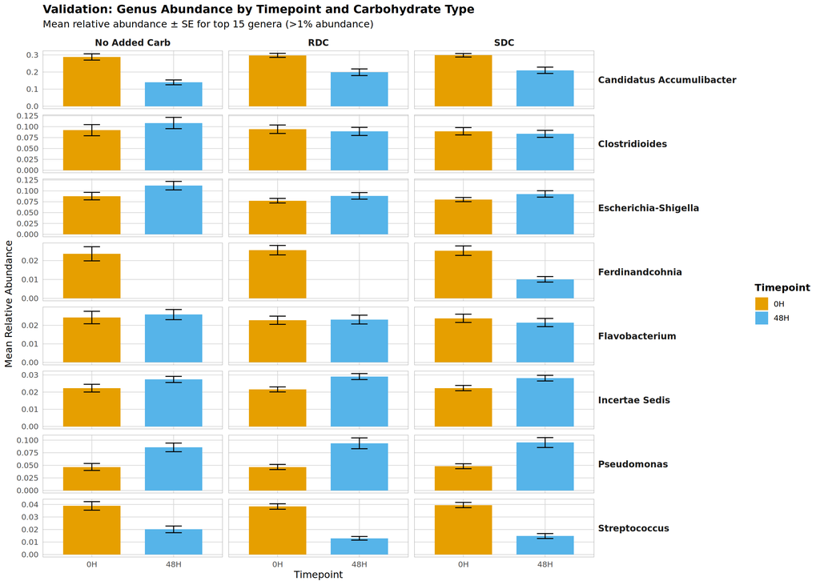

```r
# Extract genus-level data for validation
ps_genus_rel <- transform_sample_counts(ps_genus, function(x) x / sum(x))

# Get OTU table and metadata
otu_mat <- as.matrix(otu_table(ps_genus_rel))
if (!taxa_are_rows(ps_genus_rel)) {
  otu_mat <- t(otu_mat)
}
otu_df <- as.data.frame(t(otu_mat))

tax_df <- as.data.frame(tax_table(ps_genus_rel))
meta_df <- data.frame(sample_data(ps_genus_rel))

# Combine data
genus_long <- otu_df %>%
  tibble::rownames_to_column("SampleID") %>%
  tidyr::pivot_longer(-SampleID, names_to = "ASV", values_to = "Abundance") %>%
  dplyr::left_join(
    tax_df %>% tibble::rownames_to_column("ASV") %>% dplyr::select(ASV, Genus),
    by = "ASV"
  ) %>%
  dplyr::left_join(
    meta_df %>% tibble::rownames_to_column("SampleID") %>%
      dplyr::select(SampleID, Timepoint, Carbohydrate),
    by = "SampleID"
  )

# Calculate mean abundance per genus, timepoint, and carbohydrate
genus_summary <- genus_long %>%
  group_by(Genus, Timepoint, Carbohydrate) %>%
  summarise(
    mean_abundance = mean(Abundance),
    se_abundance = sd(Abundance) / sqrt(n()),
    .groups = "drop"
  ) %>%
  filter(mean_abundance > 0.01)  # Only keep genera >1% mean abundance

# Get top genera overall
top_genera <- genus_summary %>%
  group_by(Genus) %>%
  summarise(max_abundance = max(mean_abundance), .groups = "drop") %>%
  arrange(desc(max_abundance)) %>%
  head(15) %>%
  pull(Genus)

# Filter to top genera
genus_summary_top <- genus_summary %>%
  filter(Genus %in% top_genera)

# Create faceted bar plot
p_validation <- ggplot(genus_summary_top,
                       aes(x = Timepoint, y = mean_abundance, fill = Timepoint)) +
  geom_col(position = "dodge", width = 0.7) +
  geom_errorbar(aes(ymin = mean_abundance - se_abundance,
                    ymax = mean_abundance + se_abundance),
                width = 0.2, position = position_dodge(0.7)) +
  facet_grid(Genus ~ Carbohydrate, scales = "free_y") +
  scale_fill_manual(values = c("0H" = "#E69F00", "48H" = "#56B4E9")) +
  labs(
    title = "Validation: Genus Abundance by Timepoint and Carbohydrate Type",
    subtitle = "Mean relative abundance ± SE for top 15 genera (>1% abundance)",
    x = "Timepoint",
    y = "Mean Relative Abundance",
    fill = "Timepoint"
  ) +
  custom_theme() +
  theme(
    axis.text.x = element_text(angle = 0, hjust = 0.5),
    strip.text.y = element_text(angle = 0, hjust = 0),
    panel.spacing = unit(0.5, "lines")
  )

print(p_validation)
```

```r
# Print summary statistics for key changes
cat("\n### Summary of abundance changes from 0H to 48H:\n\n")
```

```
##
## ### Summary of abundance changes from 0H to 48H:
```

```r
change_summary <- genus_summary_top %>%
  dplyr::select(Genus, Timepoint, Carbohydrate, mean_abundance) %>%
  pivot_wider(names_from = Timepoint, values_from = mean_abundance,
              names_prefix = "T") %>%
  mutate(
    change = T48H - T0H,
    pct_change = ((T48H - T0H) / T0H) * 100,
    direction = case_when(
      abs(change) < 0.005 ~ "No change",
      change > 0 ~ "Increase",
      change < 0 ~ "Decrease"
    )
  ) %>%
  arrange(Carbohydrate, desc(abs(change)))

# Print changes for each carbohydrate type
for (carb in c("No Added Carb", "RDC", "SDC")) {
  cat(paste0("\n", carb, ":\n"))
  carb_changes <- change_summary %>%
    filter(Carbohydrate == carb, abs(change) > 0.01) %>%
    arrange(desc(abs(change))) %>%
    head(10)

  if (nrow(carb_changes) > 0) {
    print(carb_changes %>%
            dplyr::select(Genus, T0H, T48H, change, pct_change, direction) %>%
            mutate(across(where(is.numeric), ~round(., 4))))
  } else {
    cat("  No major changes detected (>1% absolute change)\n")
  }
}
```

```
##
## No Added Carb:
## # A tibble: 5 × 6
##   Genus                        T0H   T48H  change pct_change direction
##   <chr>                      <dbl>  <dbl>   <dbl>      <dbl> <chr>
## 1 Candidatus Accumulibacter 0.288  0.140  -0.149       -51.6 Decrease
## 2 Pseudomonas               0.0468 0.0856  0.0389       83.1 Increase
## 3 Escherichia-Shigella      0.088  0.112   0.024        27.3 Increase
## 4 Streptococcus             0.0389 0.0201 -0.0187      -48.2 Decrease
## 5 Clostridioides            0.092  0.108   0.0164       17.8 Increase
##
## RDC:
## # A tibble: 4 × 6
##   Genus                        T0H   T48H  change pct_change direction
##   <chr>                      <dbl>  <dbl>   <dbl>      <dbl> <chr>
## 1 Candidatus Accumulibacter 0.298  0.199  -0.0988      -33.2 Decrease
## 2 Pseudomonas               0.0467 0.0937  0.047       101.  Increase
## 3 Streptococcus             0.0384 0.013  -0.0254      -66.2 Decrease
## 4 Escherichia-Shigella      0.0774 0.0885  0.0111       14.4 Increase
##
## SDC:
## # A tibble: 5 × 6
##   Genus                        T0H   T48H  change pct_change direction
##   <chr>                      <dbl>  <dbl>   <dbl>      <dbl> <chr>
## 1 Candidatus Accumulibacter 0.298  0.210  -0.0878      -29.5 Decrease
## 2 Pseudomonas               0.0482 0.0953  0.0471       97.6 Increase
## 3 Streptococcus             0.0396 0.0148 -0.0248      -62.6 Decrease
## 4 Ferdinandcohnia           0.0253 0.0101 -0.0152      -60.1 Decrease
## 5 Escherichia-Shigella      0.08   0.0929  0.0129       16.2 Increase
```